# Fraud Detection

### Context

- It is important that credit card companies are able to recognize fraudulent credit card transactions so that customers are not charged for items that they did not purchase. In this project, I will build a Machine Learning model to detect fraudulent transactions based on the XGBoost algorithm.
- This dataset is fictional and is trying to simulate real life details. Any similarity to real life cases is purely coincidental. Data Source: https://www.kaggle.com/datasets/dermisfit/fraud-transactions-dataset?select=fraudTrain.csv

## 1. Import packages and checking data

### 1.1. Import packages and data

```python
import numpy as np
import pandas as pd
%matplotlib inline
import matplotlib.pyplot as plt
from matplotlib.pyplot import figure
import seaborn as sns
from sklearn.preprocessing import StandardScaler
from sklearn.model_selection import cross_val_score, KFold, train_test_split
from sklearn.linear_model import LogisticRegression
from sklearn.tree import DecisionTreeClassifier
from sklearn.ensemble import RandomForestClassifier
from datetime import date
import geopy.distance as distance
from geopy import Point
pd.set_option('display.max_column', None)
pd.set_option('display.max_row', None)
import warnings
warnings.filterwarnings('ignore')
```

```python
train = pd.read_csv("C:/Users/admin/OneDrive/Máy tính/Python Project/fraudTest.csv", parse_dates=['trans_date_trans_time', 'dob'])
test = pd.read_csv("C:/Users/admin/OneDrive/Máy tính/Python Project/fraudTrain.csv", parse_dates=['trans_date_trans_time', 'dob'])
data = pd.concat([train, test], ignore_index = False)
```

### 1.2. Checking data type and missing values

```python
print(data.info())
print(data.isna().sum())
```

```
<class 'pandas.core.frame.DataFrame'>
Index: 1852394 entries, 0 to 1296674
Data columns (total 23 columns):
 #   Column                 Dtype
---  ------                 -----
 0   Unnamed: 0             int64
 1   trans_date_trans_time  datetime64[ns]
 2   cc_num                 int64
 3   merchant               object
 4   category               object
 5   amt                    float64
 6   first                  object
 7   last                   object
 8   gender                 object
 9   street                 object
 10  city                   object
 11  state                  object
 12  zip                    int64
 13  lat                    float64
 14  long                   float64
 15  city_pop               int64
 16  job                    object
 17  dob                    datetime64[ns]
 18  trans_num              object
 19  unix_time              int64
 20  merch_lat              float64
 21  merch_long             float64
 22  is_fraud               int64
dtypes: datetime64[ns](2), float64(5), int64(6), object(10)
memory usage: 339.2+ MB
None
Unnamed: 0               0
trans_date_trans_time    0
cc_num                   0
merchant                 0
category                 0
amt                      0
first                    0
last                     0
gender                   0
street                   0
city                     0
state                    0
zip                      0
lat                      0
long                     0
city_pop                 0
job                      0
dob                      0
trans_num                0
unix_time                0
merch_lat                0
merch_long               0
is_fraud                 0
dtype: int64
```

- There are no missing values.
- The datatype of the columns is correct.

## 2. Exploratory Data Analysis

In this section I will make some hypotheses about what features determine whether a transaction is fraudulent based on the data.

### 2.1. Will fraudulent transactions occur consecutively in a short period of time based on fraud tools?

To check whether fraudulent transactions occur consecutively, I will filter records between the time of the first fraudulent transaction and the last fraudulent transaction of each cc_num.

```python
#Getting first and last fraud transaction of each cc_num
first_fraud = data[data['is_fraud']==1].groupby("cc_num")["trans_date_trans_time"].min().reset_index().rename(columns={'trans_date_trans_time':'first_fraud'})
last_fraud = data[data['is_fraud']==1].groupby("cc_num")["trans_date_trans_time"].max().reset_index().rename(columns={'trans_date_trans_time':'last_fraud'})

#Filter records that between first fraud transaction and last fraud transaction of each cc_num
data = data.merge(first_fraud, on='cc_num', how='left').merge(last_fraud, on='cc_num', how='left')
date_filter = (data['trans_date_trans_time']>=data['first_fraud']) & (data['trans_date_trans_time']<=data['last_fraud'])

data[date_filter][data['is_fraud']==0]
```

|  | Unnamed: 0 | trans_date_trans_time | cc_num | merchant | category | amt | first | last | gender | street | city | state | zip | lat | long | city_pop | job | dob | trans_num | unix_time | merch_lat | merch_long | is_fraud | first_fraud | last_fraud |
| --- | --- | --- | --- | --- | --- | --- | --- | --- | --- | --- | --- | --- | --- | --- | --- | --- | --- | --- | --- | --- | --- | --- | --- | --- | --- |
| 655909 | 100190 | 2019-02-28 18:46:17 | 6592074504369261 | fraud_Douglas-White | entertainment | 69.09 | Amanda | Molina | F | 8425 Daniel Knolls Suite 288 | Philadelphia | PA | 19154 | 40.0897 | -74.9781 | 1526206 | Commercial horticulturist | 1972-05-23 | f697822456e250ac61379115bb001b16 | 1330454777 | 40.868202 | -74.318667 | 0 | 2019-02-28 01:57:02 | 2019-03-01 22:13:27 |

So there is only 1 genuine transaction by 1 user that happens between the first and last fraudulent transaction. We can conclude that most fraudulent transactions occur consecutively, or there is only 1 fraudulent transaction for each cc_num.  
From the transaction time data, I will create a new column containing data about the time interval between transactions to see if fraudulent transactions occur in a short period of time based on the algorithms compared to genuine transactions or not.

```python
#Sort values to calculate time since last order
data = data.sort_values(['cc_num', 'trans_date_trans_time'])

#Lag transaction time
data['lag'] = data.groupby('cc_num')['trans_date_trans_time'].shift(1)

#Convert timedelta to hours
data['diff'] = (data['trans_date_trans_time'] - data['lag'])/np.timedelta64(1, 'h')
```

```python
print(data[data['is_fraud']==1]['diff'].mean(), data[data['is_fraud']==0]['diff'].mean())
```

```
5.868483873779637 8.608448378021551
```

Thus, the time interval between fraudulent transactions and genuine transactions is different, so I will use this feature in the model.

### 2.2. Do fraudulent transactions occur at specific times of the year, month or day?

I will check whether fraudulent transactions happen more often at the end of the month, the beginning of the month or at night compared to genuine transactions.

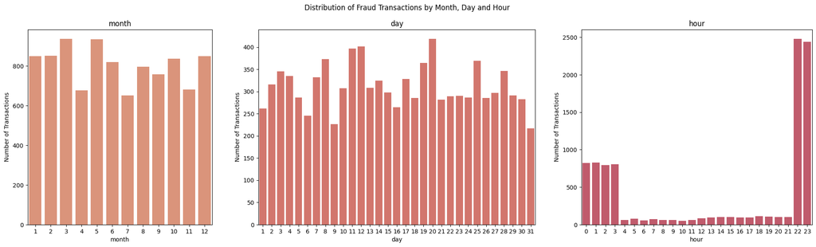

```python
import itertools
palette = itertools.cycle(sns.color_palette("flare"))

#Extract Month from transaction time
data['month']=pd.DatetimeIndex(data['trans_date_trans_time']).month

#Extract Day from transaction time
data['day']=pd.DatetimeIndex(data['trans_date_trans_time']).day

#Extract Hour from transaction time
data['hour']=pd.DatetimeIndex(data['trans_date_trans_time']).hour

#Create subplots
fig, ax = plt.subplots(1, 3, figsize=(24, 6), gridspec_kw={'width_ratios': [0.8, 1.2, 1]})
fig.suptitle('Distribution of Fraud Transactions by Month, Day and Hour')

time_list = ['month', 'day', 'hour']
for x in time_list:
    c = next(palette)
    sns.barplot(ax=ax[time_list.index(x)], x=x, y='trans_num', color=c,
                data=data[data["is_fraud"]==1].groupby(x)["trans_num"].count().reset_index()) #Count the number of fraudulent transactions occurring in months, days and hours
    ax[time_list.index(x)].set_title(x)
    ax[time_list.index(x)].set_ylabel('Number of Transactions')
    plt.xlabel(x)
```

Thus, fraudulent transactions occur seemingly randomly on days and months of the year, but there are certain fluctuations and differences between periods of the days and months. The difference in the number of fraudulent transactions can be clearly seen when considering the hours of the day, when the frequency of occurrence at night is much higher, specifically the time frame from 10pm to 3am.

### 2.3. Check fraud rate according to categorical features

First, we will see whether fraudulent transactions occur among a small number of users or the majority.

```python
print(data.groupby("cc_num")['is_fraud'].max().reset_index().groupby("is_fraud").count())
```

```
          cc_num
is_fraud
0             23
1            976
```

Most of the users have fraudulent transactions, and these fraudulent transactions occur consecutively, so these fraudulent transactions will be located among many other genuine transactions (since the rate of fraudulent transactions is very small). In some cases, a cc_num may only include fraudulent transactions without genuine transactions.

```
                                   is_fraud  trans_num
job
Ship broker                        1.000000          7
Contracting civil engineer         1.000000          7
Warehouse manager                  1.000000          7
Information officer                1.000000          8
Engineer, water                    1.000000          8
Armed forces technical officer     1.000000          8
Veterinary surgeon                 1.000000          8
Broadcast journalist               1.000000          9
Forest/woodland manager            1.000000          9
Industrial buyer                   1.000000         10
Operational investment banker      1.000000         11
Homeopath                          1.000000         11
Solicitor                          1.000000         11
Software engineer                  1.000000         11
Accountant, chartered              1.000000         11
Engineer, site                     1.000000         12
Legal secretary                    1.000000         12
Personnel officer                  1.000000         12
Sales promotion account executive  1.000000         14
Careers adviser                    1.000000         15
Air traffic controller             1.000000         17
Dancer                             1.000000         19
Engineer, materials                0.009576        731
Merchandiser, retail               0.008197        732
Local government officer           0.005464        732
Investment banker, operational     0.009550        733
Estate manager/land agent          0.008186        733
Water quality scientist            0.009537        734
Engineer, civil (consulting)       0.012262        734
Professor Emeritus                 0.005450        734
```

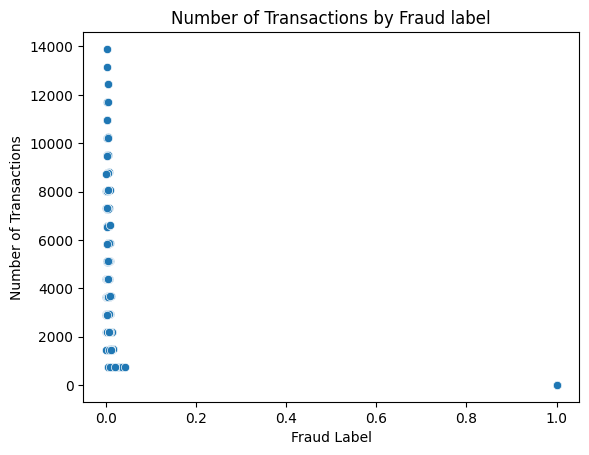

```python
#Calculate fraud rate by job and visualize on scatter plot between number of transactions and fraud rate group by job
sns.scatterplot(data=data.groupby('job').agg({'is_fraud':'mean', 'trans_num':'count'}), x="is_fraud", y="trans_num")
print(data.groupby('job').agg({'is_fraud':'mean', 'trans_num':'count'}).sort_values(by="trans_num",ascending=True).head(30))
plt.title("Number of Transactions by Fraud label")
plt.xlabel("Fraud Label")
plt.ylabel("Number of Transactions")
plt.show()
```

So it is true that there are some cases where cc_num owners have all transactions are fraudulent, with a fraud rate of 100%. Based on the table when sorting by number of transactions and scatter plot, we see that the cases with fraud rate = 100% are all cases with a very small number of transactions, specifically < 20.  
Meanwhile, other jobs with the number of transactions from 700 to 14,000, the fraud rate is very low and similar to each other. So I will classify jobs with transactions > 700 as 'others' jobs, and jobs with fraud rate = 100% I will use for One-hot encoding and put them in the model.

```python
#Generate new column based on jobs that has fraud rate = 100% and other jobs
fraud_rate = data.groupby('job').agg({'is_fraud':'mean', 'trans_num':'count'}).reset_index()
high_rate_jobs = list(fraud_rate[fraud_rate["is_fraud"]==1]["job"])
data["job"] = data["job"].apply(lambda x: 'Other' if x not in high_rate_jobs else x)
```

Next, I will check the fraud rate between categories and whether the transaction amount in each category is any different between fraud transactions and genuine transactions.

```python
#Calculate fraud rate and the average amount of money by product category
print(data.groupby('category')['is_fraud'].mean())
print(data[data['is_fraud']==1].groupby("category")['amt'].mean(), data[data['is_fraud']==0].groupby("category")['amt'].mean())
```

```
category
entertainment     0.002177
food_dining       0.001568
gas_transport     0.004106
grocery_net       0.002697
grocery_pos       0.012645
health_fitness    0.001510
home              0.001510
kids_pets         0.001880
misc_net          0.013039
misc_pos          0.002819
personal_care     0.002229
shopping_net      0.015927
shopping_pos      0.006344
travel            0.002692
Name: is_fraud, dtype: float64
category
entertainment     504.794384
food_dining       120.678829
gas_transport      12.231256
grocery_net        12.046914
grocery_pos       312.237262
health_fitness     20.277622
home              257.479094
kids_pets          18.485296
misc_net          798.654577
misc_pos          212.716894
personal_care      26.110207
shopping_net      998.128725
shopping_pos      878.913201
travel              8.970962
Name: amt, dtype: float64 category
entertainment      63.181494
food_dining        50.884652
gas_transport      63.688542
grocery_net        53.801150
grocery_pos       114.135071
health_fitness     54.139079
home               57.886732
kids_pets          57.601378
misc_net           70.689738
misc_pos           62.252334
personal_care      48.096911
shopping_net       72.194496
shopping_pos       73.799294
travel            112.048612
Name: amt, dtype: float64
```

The fraud rate of some categories is higher than the remaining categories, but this is still a low number, only about 1%.  
However, when looking at the average transaction amount of each category when divided between fraudulent transactions and genuine transactions, we clearly see a contrast in all categories.  
Specifically, in the categories **'grocery_net', 'gas_transport', 'kids_pets', 'personal_care', 'health_fitness', 'travel'**, the average transaction amount is very low in fraudulent transactions but much higher in genuine transactions. The opposite happens in the remaining categories.  
I will divide these categories into 2 types corresponding to their value in fraud transactions and then visualize them on the boxplot.

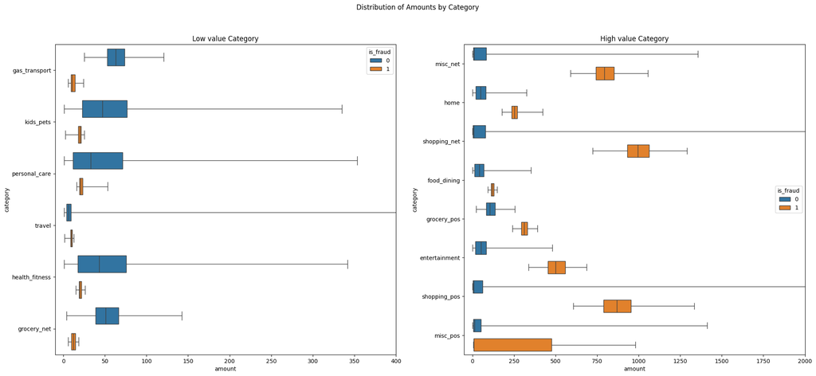

```python
#Divide between categories with low transaction value in fraud transactions
low_value_cat = ['grocery_net', 'gas_transport', 'kids_pets', 'personal_care', 'health_fitness', 'travel']
high_value_cat = ['entertainment', 'food_dining', 'home', 'grocery_pos', 'misc_net', 'shopping_net', 'shopping_pos', 'misc_pos']

fig, (ax1, ax2) = plt.subplots(1, 2, figsize=(24,10))
fig.suptitle('Distribution of Amounts by Category')

#Visualize low value category on boxplot
sns.boxplot(ax=ax1, data=data[data['category'].isin(low_value_cat)], x="amt", y="category", whis=[0.1, 99.9], width=1, hue="is_fraud", fill=True, gap=.35, fliersize=0)
ax1.set_title("Low value Category")
ax1.set_xlabel('amount')
ax1.set_xlim(-10, 400)

#Visualize high value category on boxplot
sns.boxplot(ax=ax2, data=data[data['category'].isin(high_value_cat)], x="amt", y="category", whis=[0.1, 99.9], width=1, hue="is_fraud", fill=True, gap=.35, fliersize=0)
ax2.set_title("High value Category")
ax2.set_xlabel('amount')
ax2.set_xlim(-50, 2000)
plt.show()
```

The difference is very clear between categories, as for the low value category, most of the values of genuine transactions are higher than the values of fraudulent transactions. The opposite happens in the high value category.  
Next I will check the fraud rate for each state.

```python
#Calculate fraud rate by state
print(data.groupby("state").agg({'is_fraud':'mean', 'trans_num':'count'}).sort_values(by='is_fraud', ascending=False).head(10))
```

```
       is_fraud  trans_num
state
DE     1.000000          9
RI     0.020134        745
AK     0.016875       2963
OR     0.007460      26408
NH     0.006737      11727
VA     0.006538      41756
TN     0.006382      24913
NE     0.006275      34425
MN     0.006163      45433
NY     0.006113     119419
```

So there is only one state with an unusually high fraud rate, but this state has a very small number of transactions so I will not include it in the model. Same thing with the 'city' column.

```python
#Calculate fraud rate by merchant
print(data.groupby("merchant").agg({'is_fraud':'mean', 'trans_num':'count'}).sort_values(by='is_fraud', ascending=False).head(10))
```

```
                                            is_fraud  trans_num
merchant
fraud_Kozey-Boehm                           0.021755       2758
fraud_Herman, Treutel and Dickens           0.020321       1870
fraud_Terry-Huel                            0.019553       2864
fraud_Kerluke-Abshire                       0.018975       2635
fraud_Mosciski, Ziemann and Farrell         0.018788       2821
fraud_Schmeler, Bashirian and Price         0.018651       2788
fraud_Kuhic LLC                             0.018649       2842
fraud_Jast Ltd                              0.018498       2757
fraud_Langworth, Boehm and Gulgowski        0.018459       2817
fraud_Romaguera, Cruickshank and Greenholt  0.018432       2767
```

All merchants have similar fraud rates and there is no specific merchant that is often targeted by scammers.

### 2.4. Create a few new features based on the data and check the distribution

Based on the data, I will create 2 new columns cc_type based on the length of the credit card number; The second column is the age of the users based on their profile. With these two columns, I will see if there is any relationship between card type and user age to fraud rate.  
Finally, I will create an additional column about the distance between user and merchant based on data and latitude and longitude.

```python
#Credit card type based on number of numbers
data['cc_type'] = data['cc_num'].astype(str).apply(len)

#Calculate Age of users based on dob
data['age'] = ((data.trans_date_trans_time - data.dob)/np.timedelta64(1, 'Y')).round(0)
```

```python
#Calculate the distance from the user's address to the merchant's address based on latitude and longitude
data['user_coords'] = data.apply(lambda row: Point(latitude=row['lat'], longitude=row['long']), axis=1)
data['merch_coords'] = data.apply(lambda row: Point(latitude=row['merch_lat'], longitude=row['merch_long']), axis=1)
data['distance'] = data.apply(lambda row: distance.distance(row['user_coords'], row['merch_coords']).km, axis=1)
```

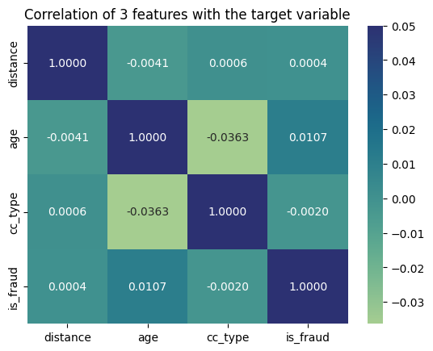

```python
#Check the correlation between the 3 newly created columns and the is_fraud column
sns.heatmap(data=data[['distance', 'age', 'cc_type', 'is_fraud']].corr(), annot=True, cmap='crest', fmt=".4f", vmax=0.05)
plt.title("Correlation of 3 features with the target variable")
plt.show()
```

Only the 'age' column has a small influence on the 'is_fraud' column. So I will keep only this column to put in the model.

## 3. Feature Engineering, Building and Evaluating Model

In this section, I will transform the categorical columns to fit the model, along with standardizing the data.

### 3.1. One-hot encoding and Dummy encoding

I will use One-hot encoding for the 'category' and 'job' columns.

```python
#Fill NaN value of diff with 0
data = data.fillna(0)

#Drop unnecessary columns
fit_data = data[['amt', 'hour', 'category', 'job', 'merch_lat', 'merch_long', 'lat', 'long', 'is_fraud', 'diff', 'age', 'city_pop', 'month', 'day']]

#One-hot encoding
fit_data = pd.get_dummies(fit_data, columns=['job', 'category'])
```

### 3.2. Standardize Data and Split Data

```python
#Split X and y
X=fit_data.drop('is_fraud', axis = 1).values
y=fit_data['is_fraud'].values

#Standardizing data
from sklearn.preprocessing import StandardScaler
scaler = StandardScaler()
model = scaler.fit(X)
X_scaled = model.transform(X)

##Train and test split
from sklearn.model_selection import train_test_split
X_train, X_test, y_train, y_test = train_test_split(X_scaled, y, test_size=0.25, random_state=41)
```

### 3.3. Choosing Model

Because this is a dataset with a high imbalance of the target column 'is_fraud', I will choose Tree-base models to use. The 2 models I chose to compare are DecisionTree and XGBoost. I have excluded RandomForest because this model is very computationally expensive.  
I will choose the metric 'Recall' to compare between the two models because for Fraud Detection, the ratio of detected transactions/total number of fraud transactions is more important than 'Precision'.

```python
#Building DecisionTree and calculate recall score
from sklearn.metrics import recall_score, confusion_matrix, classification_report
tree=DecisionTreeClassifier()
kf=KFold(n_splits=6,random_state=3, shuffle=True)
tree.fit(X_train, y_train)
tree_cv = cross_val_score(tree, X_train, y_train, cv=kf)
print(tree_cv)
tree_pred=tree.predict(X_test)
print("Recall Score: {}".format(recall_score(y_test, tree_pred)))
print(confusion_matrix(y_test, tree_pred))
print(classification_report(y_test, tree_pred))
```

```
[0.99777586 0.99796587 0.99796587 0.99782767 0.99769811 0.9976722 ]
Recall Score: 0.8202201386057888
[[460119    527]
 [   441   2012]]
              precision    recall  f1-score   support

           0       1.00      1.00      1.00    460646
           1       0.79      0.82      0.81      2453

    accuracy                           1.00    463099
   macro avg       0.90      0.91      0.90    463099
weighted avg       1.00      1.00      1.00    463099
```

```python
#Building XGBoost and calculate recall score
from xgboost.sklearn import XGBClassifier
from xgboost import plot_importance, to_graphviz
from sklearn.metrics import average_precision_score
XGB=XGBClassifier()
proba = XGB.fit(X_train, y_train).predict_proba(X_test)
xgb_pred = XGB.predict(X_test)
print('Recall Score = {}'.format(recall_score(y_test, xgb_pred)))
print(confusion_matrix(y_test, xgb_pred))
print(classification_report(y_test, xgb_pred))
```

```
Recall Score = 0.8479412963717896
[[460531    115]
 [   373   2080]]
              precision    recall  f1-score   support

           0       1.00      1.00      1.00    460646
           1       0.95      0.85      0.90      2453

    accuracy                           1.00    463099
   macro avg       0.97      0.92      0.95    463099
weighted avg       1.00      1.00      1.00    463099
```

We see that before hyperparameter tuning, XGBoost has much better performance in both Precision and Recall score than DecisionTree. So I will choose **XGBoost Model**.

### 3.4. Tuning and Building Final Model

To avoid the case where the model has a Precision score that is too low, I will choose the metric to evaluate and search for the best hyperparameter with RandomizedSearchCV as 'F1 Score'.  
I don't use GridSearchCV here due to it's computationally expensive.

```python
#Tuning hyperparameter
from sklearn.model_selection import RandomizedSearchCV
params_dt = {
    "learning_rate" : [0.25, 0.5, 0.75],
    "max_depth" : [5, 10, 15],
    "min_child_weight" : [12, 18, 24],
    "gamma" : [0, 0.1, 0.2],
    "colsample_bytree" : [0.25, 0.5, 0.75],
    "reg_lambda" : [8, 12, 16],
    "scale_pos_weight" : [15, 18, 21]
}
xgb=XGBClassifier()
kf=KFold(n_splits=6,random_state=1, shuffle=True)
random_dt = RandomizedSearchCV(xgb, param_distributions=params_dt, cv=kf, n_jobs=-1, scoring='f1', n_iter=6, verbose=3)
random_dt.fit(X_train, y_train)
best_estimators = random_dt.best_estimator_
print('Best estimators:\n', best_estimators)
best_hyperparams = random_dt.best_params_
print('Best hyperparameters:\n', best_hyperparams)
best_CV_score = random_dt.best_score_
print('Best score'.format(best_CV_score))
```

```
Fitting 6 folds for each of 6 candidates, totalling 36 fits
Best estimators:
 XGBClassifier(base_score=None, booster=None, callbacks=None,
              colsample_bylevel=None, colsample_bynode=None,
              colsample_bytree=0.5, device=None, early_stopping_rounds=None,
              enable_categorical=False, eval_metric=None, feature_types=None,
              gamma=0.1, grow_policy=None, importance_type=None,
              interaction_constraints=None, learning_rate=0.25, max_bin=None,
              max_cat_threshold=None, max_cat_to_onehot=None,
              max_delta_step=None, max_depth=15, max_leaves=None,
              min_child_weight=24, missing=nan, monotone_constraints=None,
              multi_strategy=None, n_estimators=None, n_jobs=None,
              num_parallel_tree=None, random_state=None, ...)
Best hyperparameters:
 {'scale_pos_weight': 15, 'reg_lambda': 12, 'min_child_weight': 24, 'max_depth': 15, 'learning_rate': 0.25, 'gamma': 0.1, 'colsample_bytree': 0.5}
Best score
```

After running, here are the score and the confusion matrix of the model.  
**Recall Score = 0.9005299633102324**  
**[[460398 248]**  
**[ 244 2209]]**  
However, I will slightly adjust a few hyperparameters to get a better Recall score while not worsening Precision Score too much.

```python
XGB_tuned = XGBClassifier(scale_pos_weight=18, reg_lambda=12, min_child_weight=18, max_depth=10, learning_rate=0.4, gamma=0.1, colsample_bytree=0.5)
proba_tuned = XGB_tuned.fit(X_train, y_train).predict_proba(X_test)
xgb_tuned_pred = XGB_tuned.predict(X_test)
print('Recall Score = {}'.format(recall_score(y_test, xgb_tuned_pred)))
print(confusion_matrix(y_test, xgb_tuned_pred))
print(classification_report(y_test, xgb_tuned_pred))
```

```
Recall Score = 0.9156135344476152
[[460310    336]
 [   207   2246]]
              precision    recall  f1-score   support

           0       1.00      1.00      1.00    460646
           1       0.87      0.92      0.89      2453

    accuracy                           1.00    463099
   macro avg       0.93      0.96      0.95    463099
weighted avg       1.00      1.00      1.00    463099
```

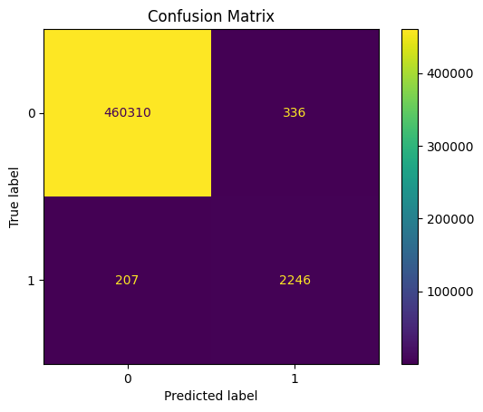

```python
from sklearn.metrics import ConfusionMatrixDisplay
cm = confusion_matrix(y_test, xgb_tuned_pred, labels=XGB_tuned.classes_)
disp = ConfusionMatrixDisplay(confusion_matrix=cm, display_labels=XGB_tuned.classes_)
disp.plot()
plt.title("Confusion Matrix")
plt.show()
```

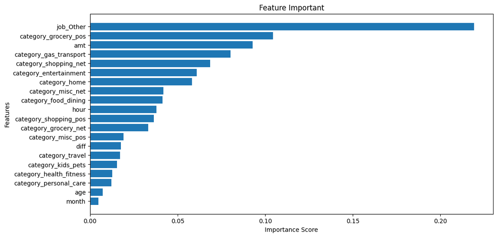

```python
feats = {} # a dict to hold feature_name: feature_importance
for feature, importance in zip(fit_data.drop('is_fraud', axis = 1).columns, XGB_tuned.feature_importances_):
    feats[feature] = importance #add the name/value pair

importances = pd.DataFrame.from_dict(feats, orient='index').rename(columns={0: 'Importance'})
importances = importances.sort_values(by='Importance', ascending=True)

importances = importances.reset_index()

# Create bar chart
plt.figure(figsize=(12, 6))
plt.barh(importances.tail(20)['index'][:20], importances.tail(20)['Importance'])

# Add labels and title
plt.xlabel('Importance Score')
plt.ylabel('Features')
plt.title('Feature Important')

# Show plot
plt.show()
```

## Conclusion:

- After tuning hyperparameters, the model has an improved accuracy index, although not the best, able to detect about **91.6%** of fraud transactions.
- The most important features for the model are **'job', 'category', 'amt', 'hour' and 'diff'**.